# Practical study of a basic genetic algorithm on the Knapsack problem

```r
summary(df_study2_large_relaxed$num_evaluations)
```

```
##     Min.  1st Qu.   Median     Mean  3rd Qu.     Max.
##     2224     6408     9639   437429    15736 50000000
```

We cannot see the boxplots as there are some extreme values corresponding (mostly) to the 0.02 value for the mutation probability. Thus, we will make a cut at 100000, which is enough as the 3rd quartile is still very far away so we won’t cut too many values:

```r
df_study2_large_relaxed %>% filter(num_evaluations > 100000)
```

| crossover_probability | mutation_probability | avg_fitness_last_pop | shannon_entropy | num_evaluations | execution_time | target_fitness_reached |
| --- | --- | --- | --- | --- | --- | --- |
| 0.6 | 0.02 | 16369.02 | 0.001816588 | 5777275 | 7.578 | TRUE |
| 0.6 | 0.02 | 16315.00 | 0.000000000 | 50000000 | 63.925 | FALSE |
| 0.6 | 0.02 | 16369.06 | 0.003633175 | 1575665 | 2.024 | TRUE |
| 0.6 | 0.02 | 16345.10 | 0.042187168 | 9735250 | 12.534 | TRUE |
| 0.6 | 0.02 | 16364.21 | 0.002724882 | 155839 | 0.203 | TRUE |
| 0.6 | 0.02 | 16356.12 | 0.001816588 | 126293 | 0.183 | TRUE |
| 0.6 | 0.02 | 16368.06 | 0.002724882 | 254588 | 0.344 | TRUE |
| 0.6 | 0.02 | 16320.49 | 0.004541469 | 4927093 | 6.378 | TRUE |
| 0.6 | 0.02 | 16365.14 | 0.004541469 | 25598667 | 33.067 | TRUE |
| 0.6 | 0.02 | 16330.52 | 0.089506530 | 2684447 | 3.494 | TRUE |

[output cut: 21 more lines]

```r
df_study2_large_relaxed_outliers_grouped <- df_study2_large_relaxed %>%
  mutate(crossover_mutation = paste0(crossover_probability, ",", mutation_probability)) %>%
  group_by(crossover_mutation) %>%
  summarise(
    avg_num_evaluations = mean(num_evaluations),
    median_num_evaluations = median(num_evaluations),
    std_num_evaluations = sd(num_evaluations),
    count = sum(num_evaluations > 100000),
    .groups = 'keep'
  ) %>%
  filter(count > 0)
df_study2_large_relaxed_outliers_grouped <- as.data.frame(df_study2_large_relaxed_outliers_grouped)
df_study2_large_relaxed_outliers_grouped
```

| crossover_mutation | avg_num_evaluations | median_num_evaluations | std_num_evaluations | count |
| --- | --- | --- | --- | --- |
| 0.6,0.02 | 3268879.7 | 25301.0 | 9977114.43 | 10 |
| 0.7,0.02 | 2323738.1 | 5573.0 | 9448029.50 | 4 |
| 0.8,0.02 | 1620491.5 | 5750.5 | 6588469.50 | 6 |
| 0.9,0.02 | 2466268.0 | 5480.0 | 9855889.94 | 4 |
| 0.9,0.04 | 12789.1 | 6200.0 | 36054.16 | 1 |
| 1,0.02 | 425063.4 | 5027.5 | 1146285.87 | 5 |
| 1,0.04 | 370596.5 | 6364.5 | 1993014.43 | 1 |

As we can see, all such extreme cases correspond to using a small mutation probability, mostly 0.02.

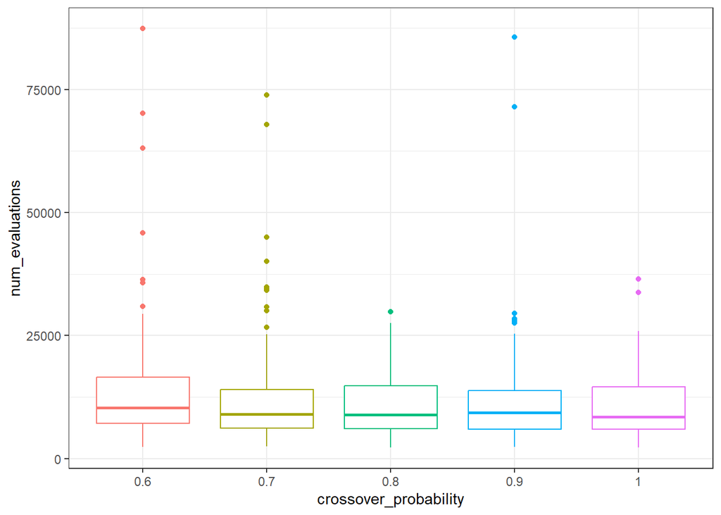

```r
df_study2_large_relaxed %>%
    filter(target_fitness_reached == TRUE, num_evaluations <= 100000) %>%
    mutate(crossover_probability = as.factor(crossover_probability)) %>%
    group_by(crossover_probability) %>%
    ggplot(mapping = aes(x = crossover_probability, y = num_evaluations, color=crossover_probability)) +
        geom_boxplot() +
        theme_bw() +
        theme(legend.position = "none")
```

The evaluated crossover probabilities seems not to have any effect on the number of evaluations.

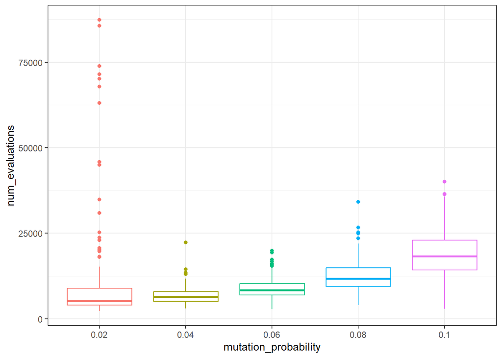

```r
df_study2_large_relaxed %>%
    filter(target_fitness_reached == TRUE, num_evaluations <= 100000) %>%
    mutate(mutation_probability = as.factor(mutation_probability)) %>%
    group_by(mutation_probability) %>%
    ggplot(mapping = aes(x = mutation_probability, y = num_evaluations, color=mutation_probability)) +
        geom_boxplot() +
        theme_bw() +
        theme(legend.position = "none")
```

This is a very odd result, since this shows that a lower mutation probability (in this range) yields better results (taking into account that, still, there are many outliers or extreme values when using a value of 0.02, but for example a value of 0.04 seems to be good enough), which is just the opposite as we saw in the previous study. Maybe it has to do with the instance nature, that is, there may be some very specific and different (in terms of genotype) solution(s) to reach the optimal but it is easy to fit a nearly-optimal one?

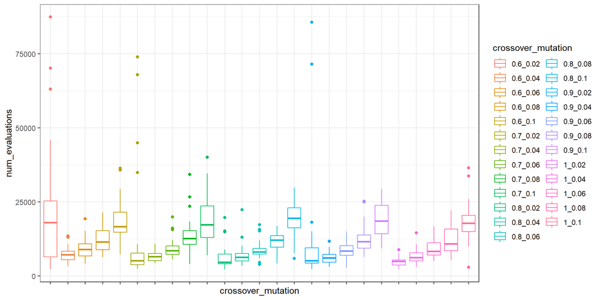

```r
df_study2_large_relaxed %>%
  filter(target_fitness_reached == TRUE, num_evaluations <= 100000) %>%
  group_by(crossover_probability, mutation_probability) %>%
  mutate(crossover_mutation = paste0(crossover_probability, "_", mutation_probability)) %>%
  ggplot(mapping = aes(x = crossover_mutation, y = num_evaluations, color=crossover_mutation)) +
    geom_boxplot() +
    theme_bw() +
    scale_x_discrete(labels = NULL)
```

```r
df_study2_large_relaxed_grouped <- df_study2_large_relaxed %>%
  mutate(crossover_mutation = paste0(crossover_probability, ",", mutation_probability)) %>%
  group_by(crossover_mutation) %>%
  summarise(
    avg_num_evaluations = mean(num_evaluations),
    median_num_evaluations = median(num_evaluations),
    std_num_evaluations = sd(num_evaluations),
    .groups = 'keep'
  )
df_study2_large_relaxed_grouped <- as.data.frame(df_study2_large_relaxed_grouped)
df_study2_large_relaxed_grouped
```

| crossover_mutation | avg_num_evaluations | median_num_evaluations | std_num_evaluations |
| --- | --- | --- | --- |
| 0.6,0.02 | 3268879.742 | 25301.0 | 9977114.426 |
| 0.6,0.04 | 7218.900 | 7154.0 | 2501.880 |
| 0.6,0.06 | 9316.967 | 8978.5 | 3256.342 |
| 0.6,0.08 | 12275.100 | 11503.5 | 4210.411 |
| 0.6,0.1 | 18609.833 | 16626.5 | 7341.702 |
| 0.7,0.02 | 2323738.097 | 5573.0 | 9448029.499 |
| 0.7,0.04 | 6630.633 | 6515.5 | 1688.079 |
| 0.7,0.06 | 9256.600 | 8560.0 | 3239.855 |
| 0.7,0.08 | 13416.200 | 12656.5 | 6221.592 |
| 0.7,0.1 | 19001.500 | 17309.0 | 7773.428 |

[output cut: 15 more lines]

At first glance, it seems that the best configuration in this case is a crossover probability of 0.7 and a mutation probability of 0.04.

```r
df_study2_large_relaxed <- as.data.frame(df_study2_large_relaxed %>%
  mutate(crossover_mutation = paste0(crossover_probability, ",", mutation_probability)))
df_study2_large_relaxed
```

| crossover_probability | mutation_probability | avg_fitness_last_pop | shannon_entropy | num_evaluations | execution_time | target_fitness_reached | crossover_mutation |
| --- | --- | --- | --- | --- | --- | --- | --- |
| 0.6 | 0.02 | 16351.70 | 0.014040957 | 87356 | 0.141 | TRUE | 0.6,0.02 |
| 0.6 | 0.02 | 16271.43 | 0.237294983 | 5668 | 0.009 | TRUE | 0.6,0.02 |
| 0.6 | 0.02 | 16317.50 | 0.003633175 | 63094 | 0.097 | TRUE | 0.6,0.02 |
| 0.6 | 0.02 | 16369.02 | 0.001816588 | 5777275 | 7.578 | TRUE | 0.6,0.02 |
| 0.6 | 0.02 | 16315.00 | 0.000000000 | 50000000 | 63.925 | FALSE | 0.6,0.02 |
| 0.6 | 0.02 | 16369.06 | 0.003633175 | 1575665 | 2.024 | TRUE | 0.6,0.02 |
| 0.6 | 0.02 | 16321.59 | 0.192271353 | 6561 | 0.000 | TRUE | 0.6,0.02 |
| 0.6 | 0.02 | 16300.15 | 0.054862107 | 12949 | 0.015 | TRUE | 0.6,0.02 |
| 0.6 | 0.02 | 16320.33 | 0.002724882 | 30947 | 0.047 | TRUE | 0.6,0.02 |
| 0.6 | 0.02 | 16357.47 | 0.031797233 | 45816 | 0.063 | TRUE | 0.6,0.02 |

[output cut: 743 more lines]

```r
# for (combination in levels(as.factor(df_study2_large_relaxed$crossover_mutation))) {
#   print(combination)
#   print(shapiro.test(
#     df_study2_large_relaxed[df_study2_large_relaxed$crossover_mutation == combination, 'num_evaluations']))
# }
```

```r
kruskal.test(num_evaluations ~ crossover_mutation, data = df_study2_large_relaxed)
```

```
##
##  Kruskal-Wallis rank sum test
##
## data:  num_evaluations by crossover_mutation
## Kruskal-Wallis chi-squared = 302.28, df = 24, p-value < 2.2e-16
```

There’s at least one combination of parameters that has a different distribution of values than the rest, let’s check it:

```r
result <- pairwise.wilcox.test(x = df_study2_large_relaxed$num_evaluations,
                               g = df_study2_large_relaxed$crossover_mutation,
                               p.adjust.method = "BH",
                               paired = FALSE)
print(result)
```

```
##
##  Pairwise comparisons using Wilcoxon rank sum exact test
##
## data:  df_study2_large_relaxed$num_evaluations and df_study2_large_relaxed$crossover_mutation
##
##          0.6,0.02 0.6,0.04 0.6,0.06 0.6,0.08 0.6,0.1 0.7,0.02 0.7,0.04 0.7,0.06
## 0.6,0.04 3.2e-05  -        -        -        -       -        -        -
## 0.6,0.06 0.00040  0.01251  -        -        -       -        -        -
## 0.6,0.08 0.00240  1.4e-06  0.00655  -        -       -        -        -
## 0.6,0.1  0.07471  3.1e-11  1.6e-08  0.00054  -       -        -        -
## 0.7,0.02 0.00460  0.53759  0.06603  0.00773  0.00250 -        -        -
## 0.7,0.04 2.3e-05  0.54105  0.00064  3.0e-09  2.0e-12 0.69077  -        -
## 0.7,0.06 0.00036  0.00749  0.83029  0.00271  2.9e-08 0.04728  0.00028  -
## 0.7,0.08 0.00413  1.7e-06  0.00226  0.58822  0.00130 0.01319  1.3e-07  0.00124
## 0.7,0.1  0.08463  2.1e-11  5.4e-09  0.00024  0.99415 0.00209  6.9e-13  3.4e-09
## 0.8,0.02 0.00513  0.78453  0.10740  0.01165  0.00124 0.78590  0.77539  0.07227
## 0.8,0.04 2.0e-05  0.54105  0.00151  5.0e-07  1.5e-10 0.79471  0.92749  0.00089
## 0.8,0.06 0.00026  0.06104  0.45580  0.00044  4.4e-09 0.10426  0.00313  0.51189
## 0.8,0.08 0.00162  8.1e-08  0.00158  0.88393  1.3e-05 0.00923  2.8e-10  0.00033
## 0.8,0.1  0.12449  3.1e-11  5.4e-09  1.2e-05  0.33033 0.00288  1.2e-11  7.5e-09
## 0.9,0.02 0.00327  0.75010  0.13568  0.01183  0.00076 0.81515  0.89301  0.09295
## 0.9,0.04 2.4e-05  0.23693  0.00035  7.3e-08  1.5e-10 0.95821  0.52641  0.00022
## 0.9,0.06 0.00015  0.05326  0.61442  0.00089  1.3e-09 0.16032  0.00341  0.76998
## 0.9,0.08 0.00394  4.6e-07  0.00470  0.82128  0.00099 0.00710  2.7e-09  0.00143
## 0.9,0.1  0.09826  1.5e-12  6.8e-10  2.7e-05  0.59692 0.00209  2.0e-14  3.2e-10
## 1,0.02   0.00042  0.04167  0.00033  2.9e-05  1.5e-05 0.68293  0.04968  0.00021
## 1,0.04   7.2e-05  0.54949  0.00271  5.4e-07  5.1e-10 0.67075  0.94832  0.00124
## 1,0.06   0.00047  0.00819  0.88393  0.00470  2.9e-08 0.04411  0.00028  0.80898
## 1,0.08   0.00230  7.9e-06  0.02594  0.88115  0.00076 0.01225  8.9e-08  0.00936
## 1,0.1    0.06603  5.3e-11  6.1e-09  6.3e-05  0.81645 0.00470  2.5e-11  6.7e-09
##          0.7,0.08 0.7,0.1 0.8,0.02 0.8,0.04 0.8,0.06 0.8,0.08 0.8,0.1 0.9,0.02
## 0.6,0.04 -        -       -        -        -        -        -       -
## 0.6,0.06 -        -       -        -        -        -        -       -
## 0.6,0.08 -        -       -        -        -        -        -       -
## 0.6,0.1  -        -       -        -        -        -        -       -
## 0.7,0.02 -        -       -        -        -        -        -       -
## 0.7,0.04 -        -       -        -        -        -        -       -
## 0.7,0.06 -        -       -        -        -        -        -       -
## 0.7,0.08 -        -       -        -        -        -        -       -
## 0.7,0.1  0.00374  -       -        -        -        -        -       -
```

[output cut: 27 more lines]

```
## 0.8,0.06 -        -        -        -       -       -       -       -
## 0.8,0.08 -        -        -        -       -       -       -       -
## 0.8,0.1  -        -        -        -       -       -       -       -
## 0.9,0.02 -        -        -        -       -       -       -       -
## 0.9,0.04 -        -        -        -       -       -       -       -
## 0.9,0.06 0.00247  -        -        -       -       -       -       -
## 0.9,0.08 3.6e-08  0.00039  -        -       -       -       -       -
## 0.9,0.1  4.2e-11  2.5e-11  0.00013  -       -       -       -       -
## 1,0.02   0.26088  0.00327  2.5e-05  1.2e-05 -       -       -       -
## 1,0.04   0.51810  0.01303  3.9e-07  9.3e-11 0.07449 -       -       -
## 1,0.06   0.00016  0.57956  0.00567  5.1e-10 0.00021 0.00195 -       -
## 1,0.08   5.4e-07  0.00374  0.73521  3.8e-05 5.5e-05 3.9e-06 0.01950 -
## 1,0.1    1.2e-09  2.8e-10  0.00025  0.69077 6.7e-05 2.4e-09 4.9e-09 0.00032
##
## P value adjustment method: BH
```

```r
GetNumberDifferentPairs(result, 0.02)
```

```
## [1] "Number of different pairs: 210"
```

We can see that this is the test where the larger number of pairs can be considered as yielding different distributions of the number of evaluations (210 out of 300 pairs). Let’s check the crossover and mutation probabilities in an isolated manner:

```r
df_study2_large_relaxed_grouped_crossover <- df_study2_large_relaxed %>%
  group_by(crossover_probability) %>%
  summarise(
    avg_num_evaluations = mean(num_evaluations),
    median_num_evaluations = median(num_evaluations),
    std_num_evaluations = sd(num_evaluations),
    .groups = 'keep'
  )
df_study2_large_relaxed_grouped_crossover <- as.data.frame(df_study2_large_relaxed_grouped_crossover)
df_study2_large_relaxed_grouped_crossover
```

| crossover_probability | avg_num_evaluations | median_num_evaluations | std_num_evaluations |
| --- | --- | --- | --- |
| 0.6 | 680515.9 | 11079 | 4653050 |
| 0.7 | 486655.8 | 9272 | 4327903 |
| 0.8 | 333479.7 | 9462 | 2977488 |
| 0.9 | 516886.7 | 9792 | 4518431 |
| 1.0 | 167130.7 | 8862 | 1031928 |

The results are not that different for each crossover probability, specially considering that the Wilcoxon tests would evaluate the medians, but still seems like the 1.0 value yields some slightly better results at first glance, let’s check it:

```r
kruskal.test(num_evaluations ~ crossover_probability, data = df_study2_large_relaxed)
```

```
##
##  Kruskal-Wallis rank sum test
##
## data:  num_evaluations by crossover_probability
## Kruskal-Wallis chi-squared = 10.401, df = 4, p-value = 0.03419
```

The p-value is small, certainly the null hypothesis could be rejected in other studies but we have used the 0.02 level of significance so far and this case is not different, so we cannot say that the different crossover probabilities yield a number of evaluations that come from different population distributions.

```r
df_study2_large_relaxed_grouped_mutation <- df_study2_large_relaxed %>%
  group_by(mutation_probability) %>%
  summarise(
    avg_num_evaluations = mean(num_evaluations),
    median_num_evaluations = median(num_evaluations),
    std_num_evaluations = sd(num_evaluations),
    .groups = 'keep'
  )
df_study2_large_relaxed_grouped_mutation <- as.data.frame(df_study2_large_relaxed_grouped_mutation)
df_study2_large_relaxed_grouped_mutation
```

| mutation_probability | avg_num_evaluations | median_num_evaluations | std_num_evaluations |
| --- | --- | --- | --- |
| 0.02 | 2033935.33 | 6102.0 | 8116662.536 |
| 0.04 | 80863.77 | 6397.5 | 891338.375 |
| 0.06 | 9025.78 | 8383.5 | 3034.596 |
| 0.08 | 12522.85 | 11697.5 | 4776.126 |
| 0.10 | 18869.42 | 18235.5 | 6585.632 |

With the mutation probability it’s likely as always so far that we there will be statistically significant differences in the number of evaluations for each value:

```r
kruskal.test(num_evaluations ~ mutation_probability, data = df_study2_large_relaxed)
```

```
##
##  Kruskal-Wallis rank sum test
##
## data:  num_evaluations by mutation_probability
## Kruskal-Wallis chi-squared = 254.98, df = 4, p-value < 2.2e-16
```

Indeed there’s at least one different distribution of values.

```r
pairwise.wilcox.test(x = df_study2_large_relaxed$num_evaluations,
                     g = df_study2_large_relaxed$mutation_probability,
                     p.adjust.method = "BH",
                     paired = FALSE)
```

```
##
##  Pairwise comparisons using Wilcoxon rank sum test with continuity correction
##
## data:  df_study2_large_relaxed$num_evaluations and df_study2_large_relaxed$mutation_probability
##
##      0.02    0.04    0.06    0.08
## 0.04 0.435   -       -       -
## 0.06 0.032   3.4e-12 -       -
## 0.08 9.5e-05 < 2e-16 3.1e-13 -
## 0.1  3.4e-08 < 2e-16 < 2e-16 < 2e-16
##
## P value adjustment method: BH
```

There are statistically significant differences between each pair of tested values except between 0.02 and 0.04, and 0.02 and 0.06. The best balance between mean, median and standard deviation seems to be obtained with a mutation probability of 0.06. This result is very different to the previously obtained ones for this problem instance, and as mentioned, it may be due to the instance’s nature as there may be some very specific and different (in terms of genotype) solution(s) to reach the optimal compared to the ones that can reach the 99%.